# Statistical Learning HW2

G04 - Domenico Spoto, Edoardo Loru, Antonio Rocca, Alessia Sgrigna

2022-06-05

# Introduction

Our task is to estimate the tempo – i.e. the rate of the pulse – of a piece of music. At our disposal we have a total of 7042 features, which can be broken down as follows:

1. $6840 = 171\times40$ Mel-frequency cepstral coefficients, which are a compression of the magnitude of a signal, obtained from its spectrogram;
2. $171$ dominant frequencies of the signal, one for each time instant
3. $8$ summary statistics extracted from `STFT` (Short-Time Fourier Transform)
4. $14$ statistical properties of the frequency spectrum
5. $6$ statistical properties of the signal
6. `genre` of the piece of music
7. `id` of the piece of music
8. `tempo` of the piece of music (the target variable)

The dataset is divided into a Training and a Testing subset, with the latter missing the `tempo` variable.

We begin by loading the Training dataset, setting aside $10$ observations which we won’t use to train the model and we will instead use in Part 2 of this task.

```r
data_import <- data.table::fread("data/train4final_hw.csv")

obs_to_be_removed <- sample(1:nrow(data_import), 10)

data <- data_import[-obs_to_be_removed ,]
```

# Part A

## Feature selection

To build our model we won’t actually use every feature: we will exclude all time-related summary statistics (such as the time initial percentile or the time interpercentile range), the `id` column - which is a unique identifier of the observation - and frequency precision of the spectrum `prec.x`, which is the same for all observations.

```r
data_to_model <- data %>%
  as_tibble() %>%
  select(-starts_with("time"), -id, -prec.x) %>%
  mutate(genre = as.character(genre))
```

## Model selection

As a model we picked a Support Vector Machine with Radial Basis Function – which is implemented in the `kernlab` package, of which we will tune the `rbf_sigma` of the RBF and the `cost` of the SVM with k-Fold Cross Validation, using `tidymodels` for all the pre-processing and modelling steps.

```r
svm_rbf_spec <- svm_rbf(cost = tune(), rbf_sigma = tune()) %>%
  set_mode("regression") %>%
  set_engine("kernlab")
```

## Exploratory Modelling

### Training/Testing split

Given that the Testing dataset provided to us doesn’t include the target variable, in order to better assess our choices and not rely solely on Kaggle – thus risking to overfit the Public LB – we decided to split the observations in the Training dataset in a 70% reserved for training/validation and a 30% for testing, using stratified sampling.

```r
tr_te_split <- data_to_model %>%
  initial_split(prop = 0.7, strata = tempo)

training <- training(tr_te_split)
testing  <- testing(tr_te_split)
```

### Pre-processing

Considering the number of features, some dimensionality reduction was necessary. The following is the approach that worked best for us

- Linear PCA on all MEL coefficients (first centered and scaled), taking the first 20 components
- Kernel PCA with RBF for all frequency and signal related features (first centered and scaled), taking the first 5 components
- One-hot encoding of `genre`

which condensed the total number of predictors from over $7000$ down to 45.

```r
svm_rbf_rec <- recipe(tempo ~ ., data = training) %>%
  step_normalize(starts_with("mel")) %>%
  step_pca(starts_with("mel"), num_comp = pca_num_comp) %>%
  step_normalize(starts_with("domfr"), starts_with("freq"),
                mean, sd, sem, median, mode, Q25, Q75, IQR, cent,
                skewness, kurtosis, sfm, sh, roughness,
                rugo, sfm.1, shannon, simpson, renyi) %>%
  step_kpca_rbf(starts_with("domfr"), starts_with("freq"),
                mean, sd, sem, median, mode, Q25, Q75, IQR, cent,
                skewness, kurtosis, sfm, sh, roughness,
                rugo, sfm.1, shannon, simpson, renyi,
                num_comp = kpca_num_comp, sigma = 0.3) %>%
  step_dummy(genre, one_hot = T)
```

This dimensionality reduction allowed us to obtain some *mild* separation between the observations with respect to their `tempo`

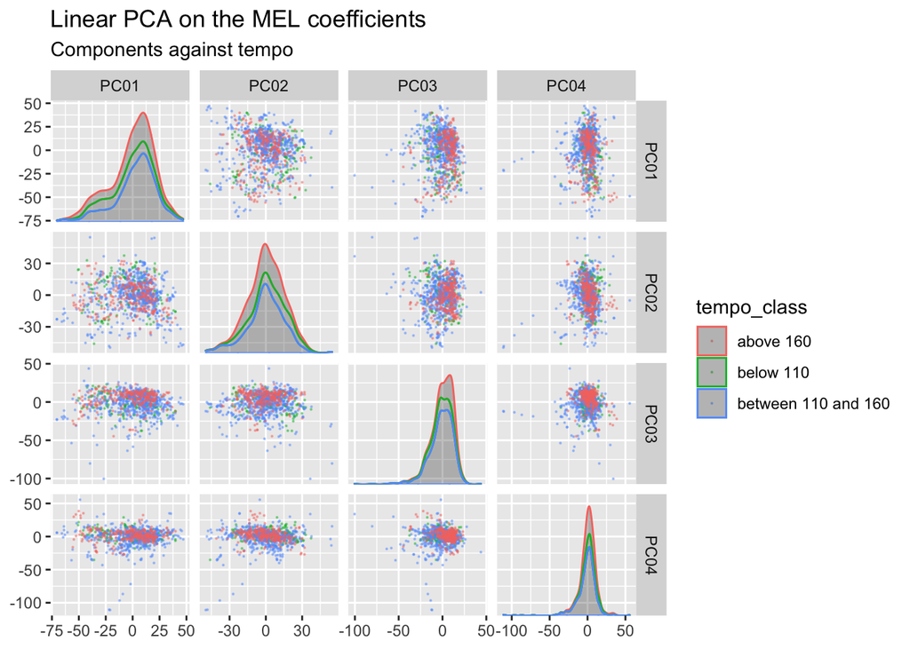

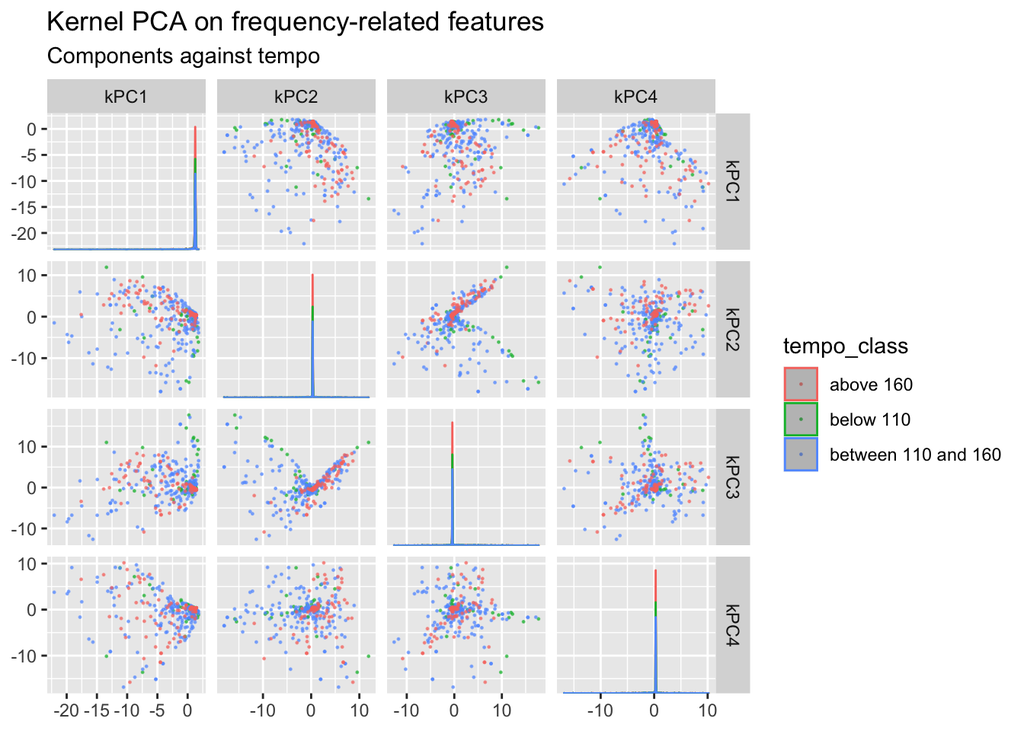

### Tuning

In order to tune the model we perform a grid search over 25 pairs of `cost` and `rbf_sigma`, using the default *sensible* values just to form an idea of the goodness of our pre-processing, and by looking at the average `RMSE` of each pair through k-fold Cross Validation with $k=5$.

```r
# training workflow
svm_rbf_wf <- workflow() %>%
  add_model(svm_rbf_spec) %>%
  add_recipe(svm_rbf_rec)

# parallel computations
cl <- makeCluster(num_cores)
plan(cluster, workers = cl)

# grid of values of cost and sigma to check
svm_rbf_grid <- grid_regular(cost(), rbf_sigma(), levels = 5)

# folds for cross validation
set.seed(123)
folds <- vfold_cv(training, v = 5, strata = tempo)

# fit for each set of folds
# for all parameters in the grid
svm_rbf_res <- svm_rbf_wf %>%
  tune_grid(resamples = folds, grid = svm_rbf_grid)
```

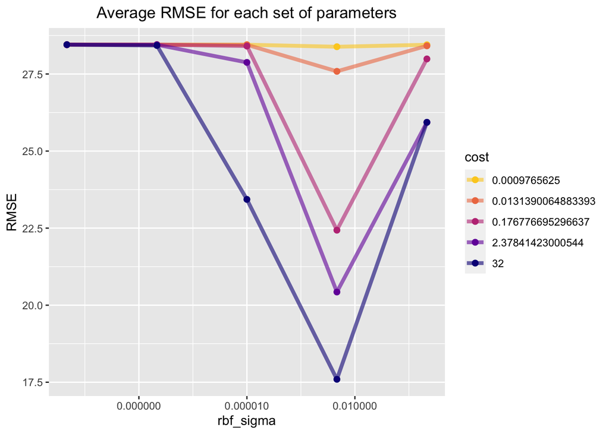

We can now fit using the `rbf_sigma` and `cost` which resulted in the lowest average `RMSE`, and compare the observed tempos against our model’s predictions.

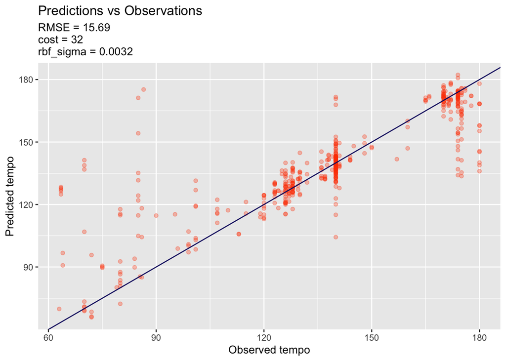

```r
best_svm <- svm_rbf_res %>% select_best("rmse")

svm_rbf_wf_final <- svm_rbf_wf %>% finalize_workflow(best_svm)

svm_rbf_fit <- svm_rbf_wf_final %>% last_fit(tr_te_split)
stopCluster(cl)
```

This plot shows us that the model doesn’t perform well when the tempo is approximately below 110. The main reason we believe this might be is that in music two pulses can be considered equal when one is a multiple of the other, and so even though the model is not predicting the actual tempo it may be “sensing” its double; this significantly influences the `RMSE`. However, we are also confident that our pre-processing has room for improvement, because it hasn’t created a great enough separation between low tempos (below 110) and the rest, as we observed earlier by plotting the principal components.

## Final Modelling (for Kaggle)

Having finalized our choices for the pre-processing, we can now use the whole Training set to train our model, using 10 folds for Cross Validation and by making a more accurate grid search.

**Remark**: the following results do not correspond to our best submission on the Public LB on Kaggle, which was obtained by **not** normalizing the features we then reduced with kPCA. In fact, we have noticed that the lowest average `RMSE` we would get this way was marginally lower (about 0.5) than the one obtained by normalizing before reducing. We are not sure on why this might be and it definitely wasn’t expected, so given that the Kaggle competition was only a side task, we decided to use the “best” results for the Final Score but to keep the “more correct” results on this report.

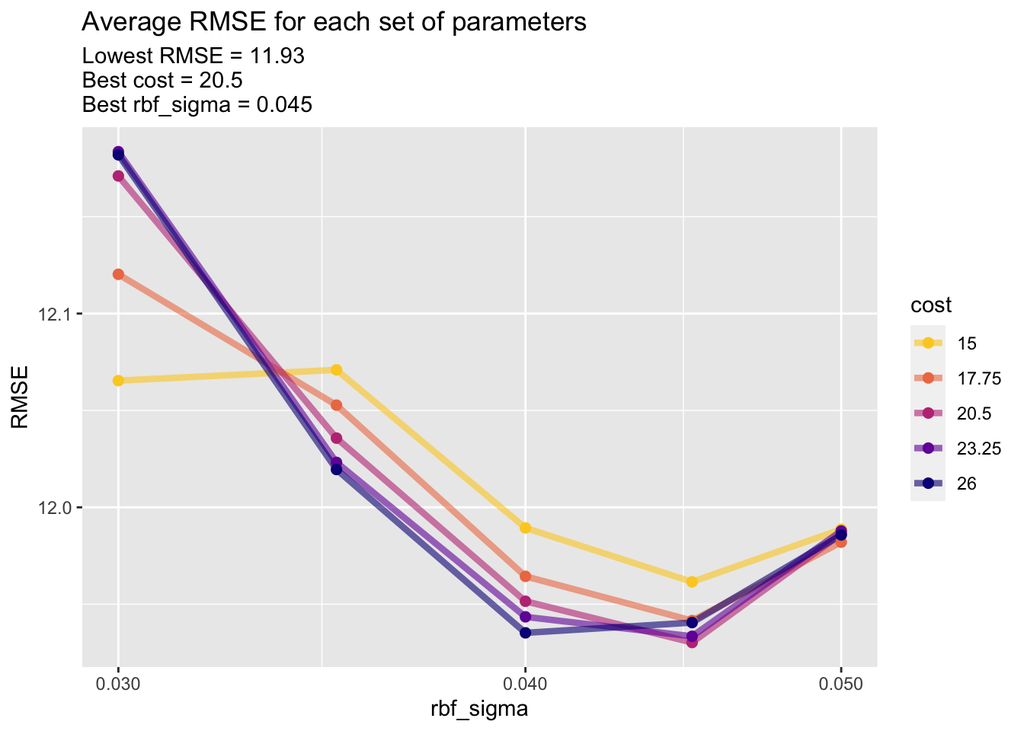

# Part B

## Point 1

We start by getting the $m$ observations that we put aside earlier; then, we select only the features we used in Part 1

```r
Xnew <- data_import[obs_to_be_removed ,] %>%
  as_tibble() %>%
  select(-starts_with("time"), -id, -prec.x) %>%
  mutate(genre = as.character(genre))
```

The Split Conformal Prediction is used to provide a confidence set to a prediction. The algorithm consists of 5 steps:

1. randomly split the Training dataset in two equal-sized subsets $D^{(1)}$ and $D^{(2)}$

```r
set.seed(222222)
D <- data_to_model
idx <- sample(1:nrow(D), floor(nrow(D)/2))

D1 <- D[idx,]
D2 <- D[-idx,]
```

2. train the model on $D^{(1)}$

```r
svm_rbf_fit_CP <- train_model(D1)
```

3. predict and evaluate on $D^{(2)}$, and compute the absolute value of the residuals

```r
resOut <- abs(D2$tempo - predict(svm_rbf_fit_CP, new_data = D2))[[1]]
```

4. compute the $d = k^{\text{th}}$ smallest value, where $k=⌈(n/2+1)(1-\alpha)⌉$ and $\alpha \in (0,1)$ is the miscoverage level

```r
alpha <- 0.025
kOut <- ceiling( ((nrow(D)/2)+1)*(1-alpha) )
resUse <- resOut[order(resOut)][kOut]
```

5. compute the $C_{\text{split}}(x) = \big[\hat{f}(x) - d, \hat{f}(x) + d\big]$ for each of the observations.

```r
Y.hat <- predict(svm_rbf_fit_CP, new_data = Xnew)[[1]]
C.split <- matrix(c(Y.hat - resUse, Y.hat + resUse, Xnew$tempo), nrow = 10, ncol = 3)
colnames(C.split) <- c('LowerCP', 'UpperCP', 'True.response')
```

Let’s compute the prediction bands for each of the $m=10$ observations for $\alpha =$ 0.025

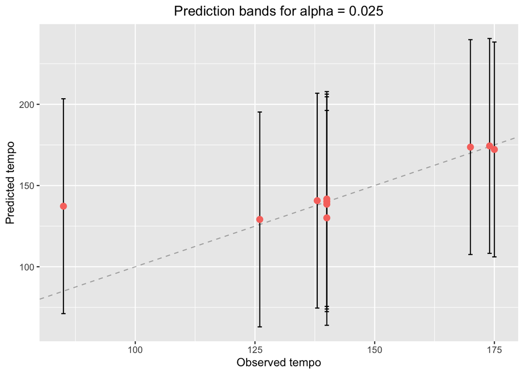

We can now plot the error rates (the frequency of an observation not being included in its prediction band) and the average band widths, expecting the former to increase linearly with the miscoverage level $\alpha$ and the latter to decrease and get closer to 0 as $\alpha$ increases.

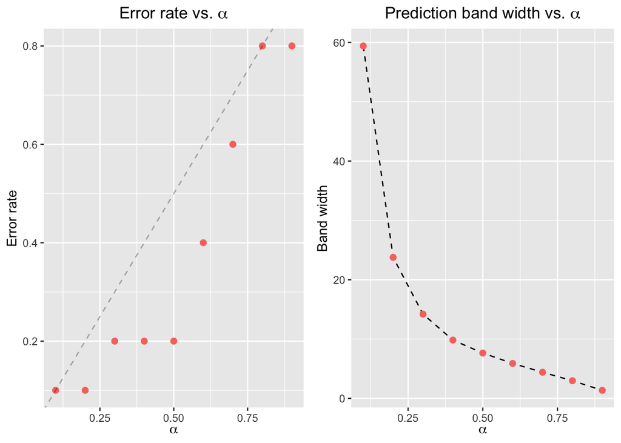

## Point 2

We now want to compute the prediction bands on 100 random observations sampled from the Testing dataset.

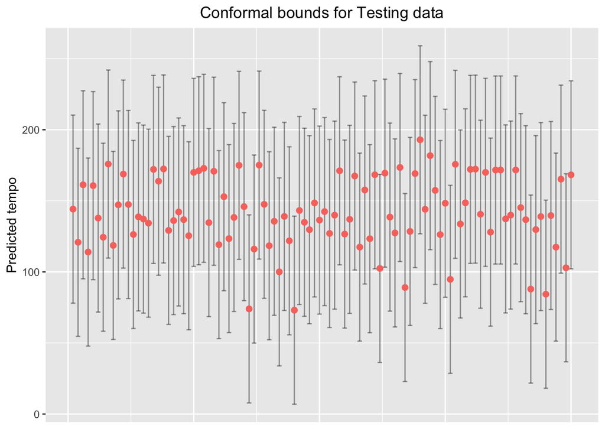